# beatochess no. 08 (February 2025)

Beat Neuenschwander, neuenschwander.beat@gmail.com, https://github.com/beatochess/

# New study

## EG no. 239 (published)

File: Neuenschwander-2025-EG-239.pgn

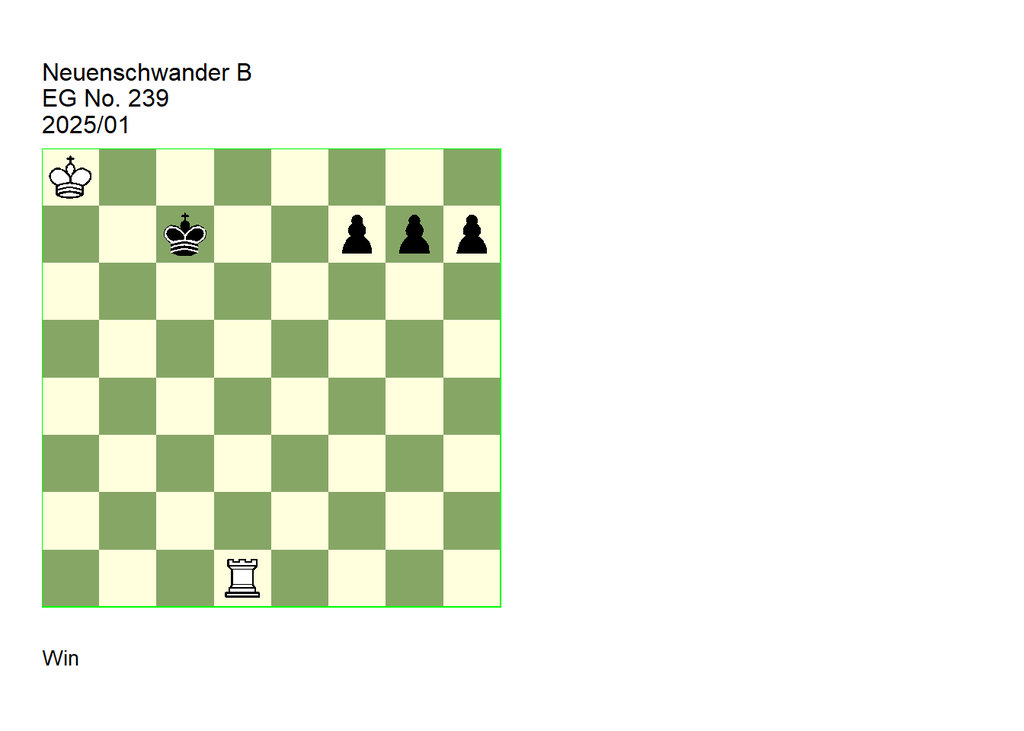

GBR: +0100.03a8c7 FEN: K7/2k2ppp/8/8/8/8/8/3R4 w - - 0 1

**1. Ka7 f6!** The most tenacious defence. (1… Kc6 2. Kb8 f5 3. Kc8 f4 4. Kd8 f3 5. Ke7 +- (5. Rf1? Kd5 6. Rxf3 Ke4 7. Rf7 g5 8. Rxh7 g4 =) ) (1… f5 2. Rd5 g6 3. Rc5+ Kd6 4. Kb6 f4 5. Kb5 +-) **2. Ka6 Kc6** (2… g5 3. Kb5 +-) **3. Ka5 Kc5 4. Ka4** (4. Rd7? g5 5. Ka4 Kc4 6. Ka3 Kc3 7. Ka2 Kc2 8. Rxh7 g4 9. Rg7 f5 =) **4… Kc4 5. Ka3** (5. Rd7? g5 6. Ka3 Kc3 etc., see 4. Rd7 ) **5… Kc3 6. Ka2 Kc2 7. Rb1!** (7. Rh1? g5 8. Rxh7 g4 9. Rg7 f5 =) **7… g5** (7… f5 8. Rb2+ Kd3 9. Kb1 g5 transposes to the **main** line ) **8. Rb2+ Kd3 9. Kb1 g4 10. Kc1 f5 11. Kd1 1-0**.

# Comments and revisions

## Prize winners

Date: February 2, 2025

File: Amiryan1981a.pgn

The version keeps some of the contents of Amiryan’s study.

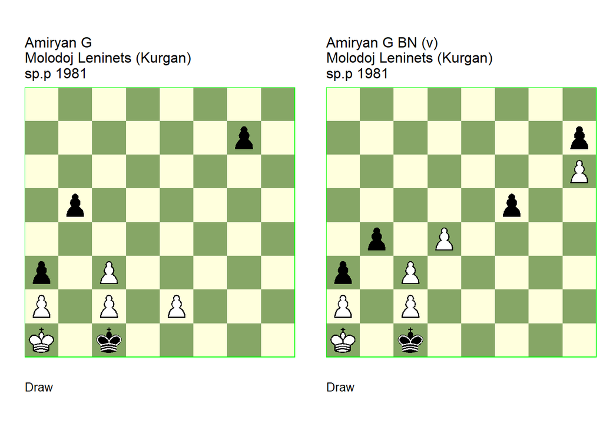

GBR: =0000.43a1c1 U3 FEN: 8/6p1/8/1p6/8/p1P5/P1P1P3/K1k5 w - - 0 1

EG#05115. U3: Mihoci=I HHdbIV#49883 5-11-2007 U3: Garcia=M HHdbV#33094 22-9-2011. **1. e4 g5 2. e5 g4 3. e6 g3 4. e7 g2 5. e8=Q g1=Q 6. Qe2 Qh1** (6… Qd1! **cook** MG 7. Qf2 Qh1 8. Qe2 Qg1 9. Qd3 Qe1) **7. Qf2 Qd1 8. Qd4 Qe1 9. Qe5 Qh1** (9… Kd2+! **cook** IM 10. Qxe1+ Kxe1 11. Kb1 Kd1 12. Ka1 Kc1 13. c4 bxc4 14. c3 Kd1 15. Kb1 Kd2 16. Ka1 Kxc3 17. Kb1 Kd2) **10. Qh8 Qf1 11. Qf6 1/2-1/2**.

GBR: =0000.54a1c1 (v) FEN: 8/7p/7P/5p2/1p1P4/p1P5/P1P5/K1k5 w - - 0 1

version: Neuenschwander=B beatochess 02/02/2025. **1. d5 f4 2. d6 f3 3. d7 f2 4. d8=Q f1=Q! 5. Qf6 Qg1 6. Qd4** (6. Qg7? Qh1) **6… Qf1** (6… Qh1 7. Qf2) **7. Qf6 Qe1 8. Qe5 Qd1 9. Qd4** (9. Qh2? Qf1!) **9… Qf1 10. Qf6 Qe1 11. Qe5 1/2-1/2**.

### Missiaen =0131.15h6d7 (1981). Cook

Date: February 3, 2025

File: Missiaen1981a.pgn

Black seems to be winning after **1… Ba3! 2. Rxg4 e2 3. Rg1 Ke7!**.

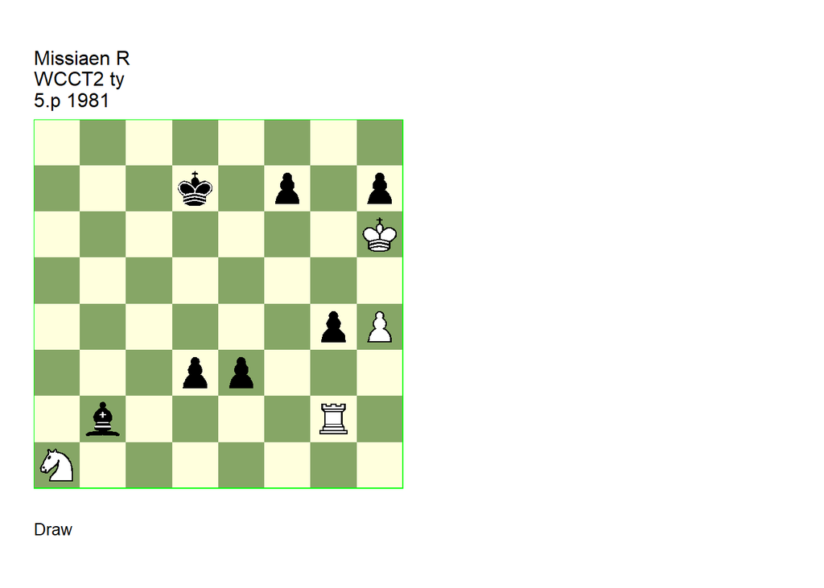

GBR: =0131.15h6d7 TT U3 FEN: 8/3k1p1p/7K/8/6pP/3pp3/1b4R1/N7 w - - 0 1

WCCT2 ty 1980-1981 EG#05362. Neuenschwander=B beatochess 03/02/2025. **1. Nb3** ( 1. Rxb2? d2 2. Rb1 e2) (1. Nc2? e2 2. Rxe2 dxe2 3. Kxh7 Bc3) **1… d2** (1… e2 2. Nc5+) (1… Ba3 2. Rxg4 d2 (2… e2 3. Rg1 Bb4 (3… Ke7! **cook** **BN** 4. Kxh7 (4. Kg5 Bb4 5. Nd4 Bc3) 4… Bc5 5. Ra1 Bf2 6. h5 e1=Q 7. Rxe1+ Bxe1) 4. Kg7 d2 (4… Ke7 5. Nc1 e1=Q 6. Rxe1+ Bxe1 7. Nxd3) 5. Nxd2 Bxd2 6. Kxf7) 3. Nxd2 Bc1 4. Nf3 e2+ 5. Kxh7) **2. Nxd2** (2. Rxd2+? exd2 3. Nxd2 Bc1) (2. Rg1? Bc3) **2… Bc1! 3. Kh5** (3. Nb3? e2+) (3. Rxg4? Bxd2 4. Re4 f5) (3. Kxh7? exd2 4. Rg1 g3) **3… exd2 4. Rxg4** (4. Rg1? f5 5. Rd1 h6 6. Kxh6 Ke6 7. Kg5 Ke5 8. h5 g3 9. h6 (9. Kh4 Kf4 10. Rf1+ Ke3 11. Kxg3 Ke2) 9… g2 10. h7 g1=Q+ 11. Rxg1 d1=Q+) **4… Ke6** (4… d1=Q) (4… d1=B) (4… d1=R 5. Rd4+ Rxd4) **5. Rd4** (5. Rg1? Kf5 6. Rd1 Kf4) **5… Ke5 6. Rd7 f5** (6… f6 7. Kg4) (6… Ke6 7. Rd3 Kf5 8. Rxd2 Bxd2) **7. Rxd2 Bxd2 1/2-1/2**.

### Mihajloski +0440.31h5f7 (1981). Cook

Date: February 3, 2025

File: Mihajloski1981a.pgn

**2… Bd7+!** cooks the study.

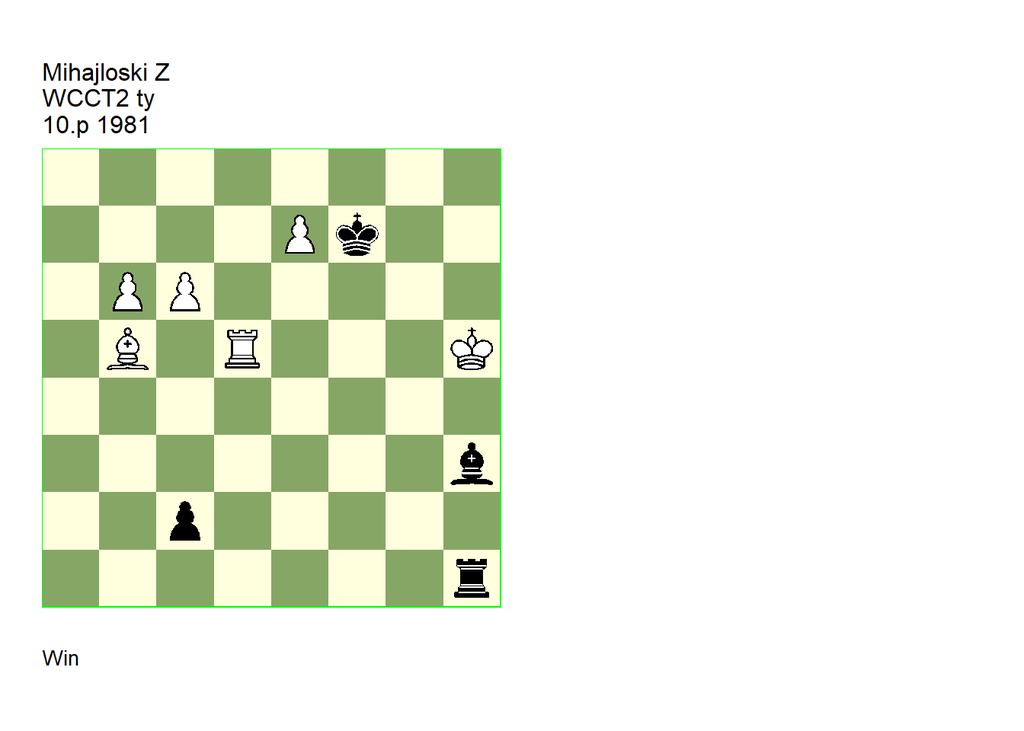

GBR: +0440.31h5f7 TT U3 FEN: 8/4Pk2/1PP5/1B1R3K/8/7b/2p5/7r w - - 0 1

WCCT2 ty 1980-1981 EG#05367. U3: Neuenschwander=B beatochess 03/02/2025. **1. e8=Q+** (1. Rc5? Bc8+ 2. Kg5 c1=Q+ 3. Rxc1 Rxc1 4. b7 Rc5+ 5. Kh6 Bxb7 6. e8=Q+ Kxe8 7. cxb7+ Rxb5) **1… Kxe8 2. Rc5** (2. b7? c1=Q 3. b8=Q+ Bc8+ 4. Kg6 Qh6#) **2… Bc8+** (2… Kd8 3. Rxc2 Bf5+ 4. Kg5 Bxc2 5. c7+ Kc8 6. Ba6+) (2… Bf5+ 3. Kg5 Rb1 4. Ba4 Bc8 5. b7 Bxb7 6. cxb7+ Kd8 7. Rc6 c1=Q+ 8. Rxc1 Rxc1 9. b8=Q+) (2… Bd7+! **cook** **BN** 3. Kg6 (3. Kg5 c1=Q+ 4. Rxc1 Rxc1) 3… Ke7 4. b7 (4. Rxc2 Be8+ 5. Kf5 Rh5+) 4… Be8+ 5. Kg7 Rg1+) **3. Kg6** (3. Kg5? c1=Q+ 4. Rxc1 Rxc1 5. b7 Rc5+ 6. Kf6 Bxb7 7. cxb7+ Rxb5) **3… Rg1+ 4. Kf6 c1=Q** (4… Rb1 5. b7 Bxb7 6. cxb7+ Rxb5 7. Rxb5 c1=Q 8. b8=Q+) **5. Rxc1 Rxc1 6. b7 Rxc6+ 7. Bxc6+ Kd8 8. b8=R** (8. b8=Q?) **8… Kc7 9. Ra8 1-0**.

### Halski & Rusinek =0413.33d6g6 (1981). Cook

Date: February 3, 2025

File: Halski1981a.pgn

Black has a large advantage after **1… Rb6+!**.

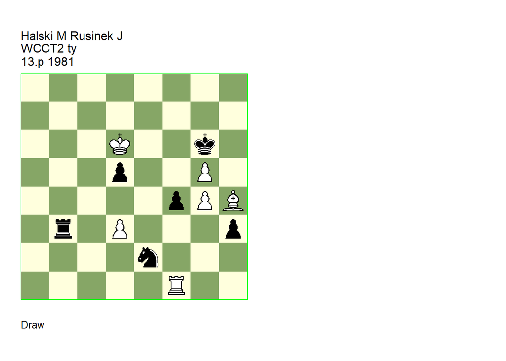

GBR: =0413.33d6g6 TT U3 FEN: 8/8/3K2k1/3p2P1/5pPB/1r1P3p/4n3/5R2 w - - 0 1

WCCT2 ty 1980-1981 EG#05370. Neuenschwander=B beatochess 03/02/2025. **1. Rf2** ( 1. Kxd5? Rxd3+ 2. Ke4 Re3+ 3. Kd5 Ng3) **1… Ng1** (1… Ng3 2. Ke5 (2. Kxd5? Rxd3+ 3. Ke5 Ne2 4. Rxe2 Re3+) 2… Rxd3 3. Kxf4 Ne4 4. Ra2) (1… Rb6+! **cook** **BN** 2. Kc5 (2. Kxd5 Rb2) 2… Re6 3. Rh2 (3. Kxd5 Re3 4. d4 Ng1) 3… Re3 4. d4 Nc3) **2. Kxd5 Rxd3+ 3. Ke4** (3. Ke5? Ne2) **3… Re3+ 4. Kxf4 Rf3+ 5. Rxf3 h2 6. Rh3 Nxh3+ 7. Kg3 h1=Q** (7… h1=R 8. Kg2) **1/2-1/2**.

### Nestorescu =0301.31b2g8 (1983). Cook, correction

Date: February 4, 2025

File: Nestorescu1983a.pgn

Black wins after **1… Kg7 2. a7 Rf8 3. Kc1 Rd8!**. The study can be saved by an additional white pawn.

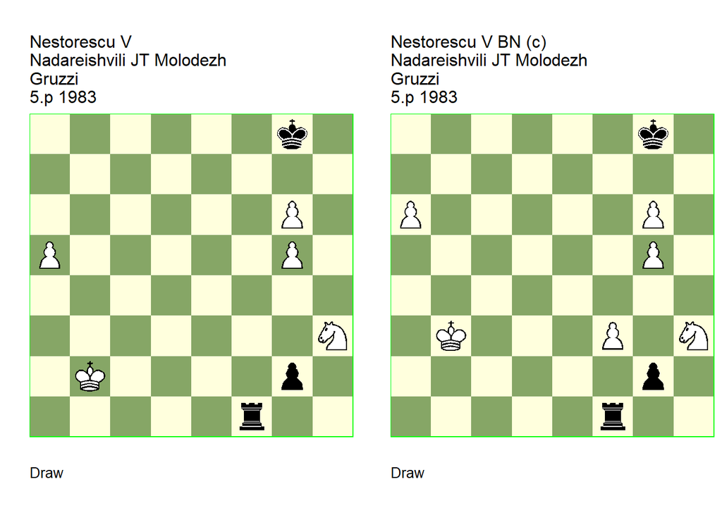

GBR: =0301.31b2g8 U3 FEN: 6k1/8/6P1/P5P1/8/7N/1K4p1/5r2 w - - 0 1

EG#05379. U3: Neuenschwander=B beatochess 04/02/2025. **1. a6 Rf2+** (1… Kg7 2. a7 Rf8 3. Kc1 Kxg6 (3… Ra8 4. Kd2 Rxa7 5. Ke2 Ra3 6. Ng1 Rg3 7. Kf2 Rxg5 8. Nf3 Rxg6 9. Kg1) (3… Rd8! **cook** **BN** 4. Kc2 Ra8 5. Kd2 Rxa7 6. Ke2 Ra3 7. Ng1 Kxg6 8. Kf2 Ra2+ 9. Kf3 Kxg5 10. Kg3) 4. a8=Q Rxa8 5. Nf4+ Kxg5 6. Nxg2 Ra1+ 7. Kb2) (1… Rd1 2. a7 Rd8 3. Kc2 Kg7 4. Kc3) **2. Kb3!** (2. Kb1? Rf3 3. a7 Ra3 4. Kc2 Rxa7 5. Kd2 Ra1) (2. Kc1? Ra2 3. Kd1 g1=Q+ 4. Nxg1 Ra1+ 5. Kc2 Rxg1) (2. Ka3? Kg7! 3. Kb4 (3. Kb3 Rf3+ 4. Ka4 Rxh3) (3. a7 Rf8 4. Kb2 Ra8 5. Kc2 Rxa7 6. Kd2 Ra1) 3… Ra2 4. Kb5 Ra1! 5. Kb6 Rh1 6. a7 Rxh3 7. a8=Q g1=Q+) **2… Rf3+** (2… Kg7 3. a7! (3. Kc4? Ra2) 3… Rf8 4. Kc4) **3. Ka4! Rxh3** (3… Rf1 4. Kb5) **4. a7 Rh4+** (4… g1=Q **main** 5. a8=Q+ Kg7 6. Qb7+ Kxg6 7. Qb6+ Qxb6) **5. Ka3! g1=Q 6. a8=Q+ Kg7 7. Qb7+ Kxg6 8. Qb1+! Qxb1 1/2-1/2**.

GBR: =0301.41b3g8 (c) FEN: 6k1/8/P5P1/6P1/8/1K3P1N/6p1/5r2 w - - 0 1

correction: Neuenschwander=B beatochess 04/02/2025. **1. Kb2!** (1. Ka2 Rd1) **1… Rf2+** (1… Rd1 2. a7 Rd8 3. Kc2 Ra8 4. Kd2 Rxa7 5. Ke2) **2. Kb3** (2. Ka3 or ) **2… Rxf3+ 3. Ka4 Rxh3 4. a7 Rh4+** (4… g1=Q **main** 5. a8=Q+ Kg7 6. Qb7+ Kxg6 7. Qb6+ Qxb6) **5. Ka3 g1=Q 6. a8=Q+ Kg7 7. Qb7+ Kxg6 8. Qb1+ Qxb1 1/2-1/2**.

### Gogberashvili =3015.22f6a8 (1983). Cook, correction

Date: February 5, 2025

File: Gogberashvili1983a.pgn

There is the additional cook **10. Be5!** in the mainline.

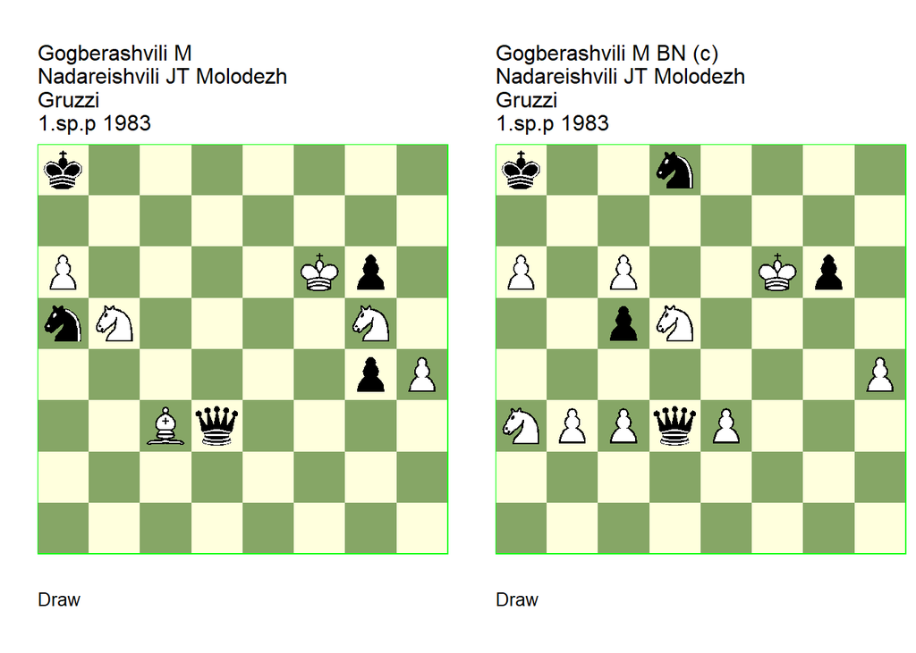

GBR: =3015.22f6a8 U3 U2 FEN: k7/8/P4Kp1/nN4N1/6pP/2Bq4/8/8 w - - 0 1

EG#05382. U3: Garcia=M HHdbV#30517 24-9-2011.U2: Neuenschwander=B beatochess 05/02/2025. **1. Ne6 Nc6** (1… Qf3+! **cook** MG 2. Kxg6 Nc6 3. Bd4 g3 4. Nec7+ Kb8 5. a7+ Nxa7 6. Bxa7+ Kb7) **2. Nec7+ Kb8 3. a7+ Nxa7 4. Na6+ Kc8** (4… Ka8 5. Nbc7+) **5. Nxa7+ Kd8 6. Nc6+ Ke8 7. Nc7+ Kf8 8. Ne6+ Kg8 9. Ne7+ Kh7** ( 9… Kh8 10. Be5) **10. Kf7** (10. Bd4? Qf1+ 11. Kg5 g3) (10. Be5! **cook** **BN** 10… g3 (10… Qf1+ 11. Bf4) 11. Bf4 Qc3+ 12. Kf7 Qb3 13. Kf6) **10… Qxc3 11. Nf8+ Kh6 12. Ng8+ Kh5 13. Nf6+ Kxh4 14. Nxg6+ Kh3 15. Nf4+ Kh2 16. Nxg4+ Kh1 17. Nf2+ Kh2 18. Ng4+ Kh1 19. Nf2+ 1/2-1/2**.

GBR: =3005.62f6a8 (c) FEN: k2n4/8/P1P2Kp1/2pN4/7P/NPPqP3/8/8 w - - 0 1

correction: Neuenschwander=B beatochess 05/02/2025. **1. Nb5** (1. c7? Qxa6+ 2. Kg7 (2. Ke7 Qe6+ 3. Kxd8 Qxd5+) 2… Ne6+) **1… Nxc6** (1… Qf5+ 2. Ke7 Qe6+ 3. Kxd8 Qxd5+ 4. Kc8 Qe6+ 5. Kc7 Qxe3 6. c4) **2. Ndc7+ Kb8 3. a7+ Nxa7 4. Na6+ Kc8 5. Nxa7+ Kd8 6. Nc6+ Ke8 7. Nc7+ Kf8 8. Ne6+ Kg8 9. Ne7+ Kh7 10. Kf7 Qxc3** ( 10… Qxe3 11. Nf8+ Kh6 12. Ng8+ Kh5 13. Nxg6 Kg4 14. Nf6+ Kf3 15. Nd5 Qe4 16. c4) **11. Nf8+ Kh6 12. Ng8+ Kh5 13. Nf6+ Kxh4 14. Nxg6+ Kh3 15. Nf4+ Kh2 16. Ng4+ Kh1 17. Nf2+ Kh2 18. Ng4+ Kh1 19. Nf2+ 1/2-1/2**.

### Seckar =0431.22d2a8 (1974). Cook

Date: February 6, 2025

File: Seckar1974a.pgn

The mainline does not work due to **6… Kc8!**.

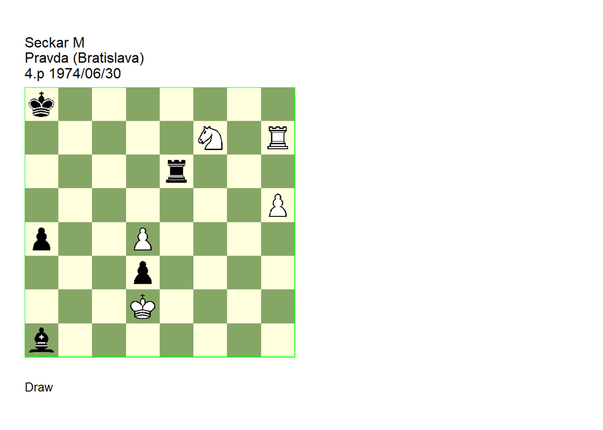

GBR: =0431.22d2a8 U1 U3 FEN: k7/5N1R/4r3/7P/p2P4/3p4/3K4/b7 w - - 0 1

EG#02429. U1: Garcia=M HHdbV#41022 6-2-2009. U3: Neuenschwander=B beatochess 06/02/2025. **1. Nd8** (1. d5! **cook** MG ) (1. Kxd3! **cook** MG ) **1… Rd6 2. Nb7 Rxd4 3. Rc7 Kb8 4. Re7 Bc3+ 5. Kxc3 d2 6. Na5 Rd3+** (6… Kc8! **cook** **BN** 7. Nc6 Rd6) **7. Kxd3 d1=Q+ 8. Kc4 Kc8 9. Nc6 1/2-1/2**.

### Joitsa =0131.03h6g1 (1981). Correct?

Date: February 6, 2025

File: Joitsa1981a.pgn

John Nunn’s **2… g3** does not seem to win for Black.

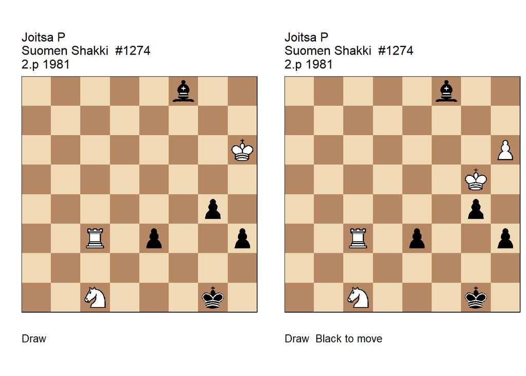

GBR: =0131.03h6g1 U3 FEN: 5b2/8/7K/8/6p1/2R1p2p/8/2N3k1 w - - 0 1

Suomen Shakki=11 Suomen Shakki/11 (EG#05455). U3: Nunn=J HHdbIII#20531 31-8-2002. Comment: Neuenschwander=B beatochess 06/02/2025. **1. Kg5!** (1. Kg6? h2 2. Rxe3 Bb4 3. Rd3 Be1 4. Rd1 Kf2 5. Nd3+ Ke2 6. Rxe1+ Kxd3 7. Kg5 g3) **1… h2 2. Nd3** (2. Rxe3? Bh6+ 3. Kxg4 Bxe3 4. Ne2+ Kg2 5. Ng3 Bf2) (2. Ne2+? Kf2 3. Rc1 g3 4. Nxg3 Kxg3) **2… Bh6+!** (2… g3! **cook** JN 3. Rc1+! **BN** 3… Kg2 4. Nf4+ Kf2 5. Kg4 g2 6. Nxg2 Kxg2 7. Rc2+ Kg1 8. Rc1+ Kf2 9. Kh3 =) **3. Kxg4 e2 4. Rb3!** (4. Ra3? Bg7 5. Rb3 e1=Q 6. Nxe1 h1=Q 7. Nf3+ Kf2) (4. Rc2? Kf1 5. Rb2 Bc1! 6. Rb1 e1=Q 7. Nxe1 h1=Q 8. Rxc1 Ke2 9. Rc2+ Kd1) **4… e1=Q** (4… Bc1 5. Rb1 e1=Q 6. Nxe1 h1=Q 7. Rxc1 Qe4+ 8. Kg3 Qe5+ 9. Kf3 Qh5+ 10. Ke4 Qe2+ 11. Kd4 Qb2+ 12. Rc3 Qf2+ 13. Re3) **5. Nxe1 h1=Q 6. Ng2! Qh2** (6… Kxg2 7. Rb2+) (6… Qxg2+ 7. Rg3) (6… Bc1 7. Rh3) **7. Rb1+ Kf2 8. Rb2+ 1/2-1/2**.

GBR: =0131.13g5g1 (c) FEN: 5b2/8/7P/6K1/6p1/2R1p2p/8/2N3k1 b - - 0 1

Suomen Shakki=11 Suomen Shakki/11. correction: Garcia=M Estudios Artisticos de Ajedrez - XVI-78 2015. **1… h2 2. Nd3!** (2. Rd3? Kf2 3. Rd1 g3 4. Rh1 ( 4. Nd3+ Ke2) 4… Kf3 5. h7 Bg7) **2… Bxh6+ 3. Kxg4 e2 4. Rb3!** (4. Ra3? Bg7 5. Rb3 e1=Q 6. Nxe1 h1=Q 7. Nf3+ Kf2) (4. Rc2? Kf1 5. Rb2 Bc1 6. Rb1 e1=Q 7. Nxe1 h1=Q) **4… e1=Q** (4… Bc1 **main** 5. Rb1 e1=Q 6. Nxe1 h1=Q 7. Rxc1 Qe4+ 8. Kg3 Qg6+ 9. Kf3 Qh5+ 10. Ke4 Qg4+ 11. Kd3!) **5. Nxe1 h1=Q 6. Ng2 Qh2 7. Rb1+ Kf2 8. Rb2+ 1/2-1/2**.

### Israelov & Sarychev =0302.12c3h7 (1980). Cook

Date: February 7, 2025

File: Israelov1980a.pgn

**7. h4!** cooks the study.

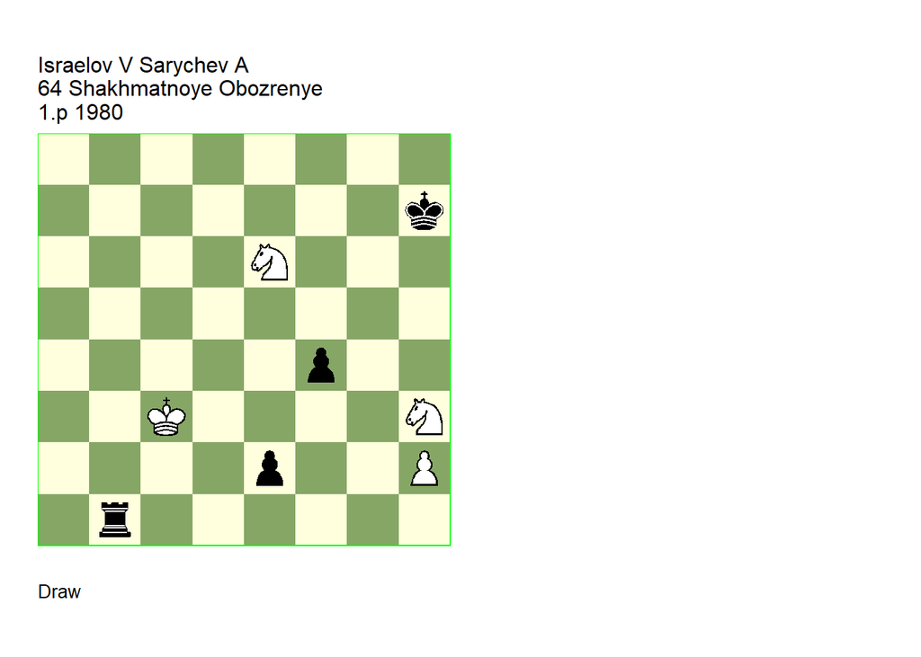

GBR: =0302.12c3h7 U2 FEN: 8/7k/4N3/8/5p2/2K4N/4p2P/1r6 w - - 0 1

64 Shakhmatnoye Obozrenye=24(624) 64 Shakhmatnoye Obozrenye/12 also Azerbaijan ty 1983 EG#05468. U2: Neuenschwander=B beatochess 07/02/2025. **1. Nhg5+** (1. Neg5+? Kh6 2. Nf3 Rf1 3. Kd2 Rxf3 4. Ng1 Re3 5. Nxe2 Kg5) (1. Kd2) **1… Kh6** (1… Kh8 2. Nf3) **2. Nf7+ Kh7 3. Nfg5+ Kg8! 4. Nf3 Rf1** (4… e1=Q+ 5. Nxe1 Rxe1 6. Nxf4) **5. Kd2!** (5. Ned4? e1=Q+ 6. Nxe1 Rxe1) (5. Neg5? e1=Q+ 6. Nxe1 Rxe1) **5… Rxf3 6. Ke1!** (6. Kxe2? Re3+) **6… Kh8 7. h3!** (7. h4! Kg8 8. h5 Kh8 9. h6 Kg8 10. h7+ Kh8 11. Nf8! **cook** **BN** ) **7… Kg8 8. h4 Kh8 9. h5 Kg8 10. h6 Kh8 11. h7 Kxh7 12. Ng5+ 1/2-1/2**.

### Mitrofanov +0113.03b4b6 (1980). Not cooked

Date: February 7, 2025

File: Mitrofanov1980a.pgn

**1. Bb8** does not seem to be a cook.

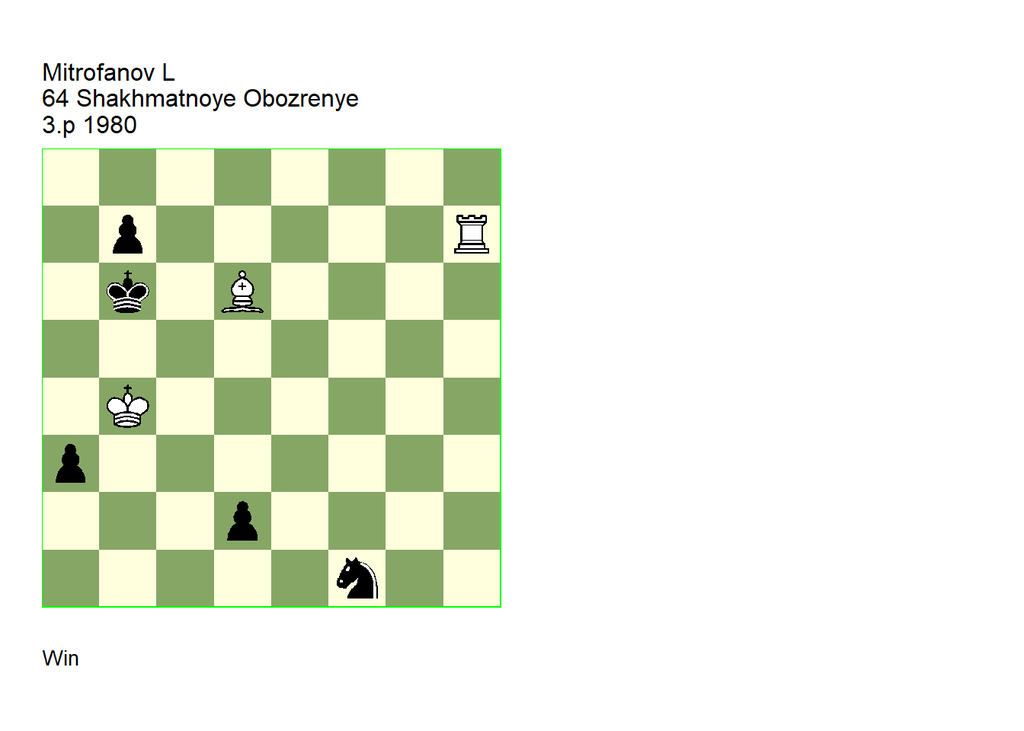

GBR: +0113.03b4b6 FEN: 8/1p5R/1k1B4/8/1K6/p7/3p4/5n2 w - - 0 1

64 Shakhmatnoye Obozrenye=5(604) 64 Shakhmatnoye Obozrenye/3 (EG#05470). U1: De, Zeeuw=M HHdbIV#47959 4-9-2005. Comment: Neuenschwander=B beatochess 07/02/2025. **1. Rh6!** (1. Bb8! **cook** MZ 1… Kc6 2. Rc7+! Kd5 (2… Kb6 3. Rd7) 3. Rf7 Ne3 (3… Ke4! no **cook** **BN** 4. Rxf1 Kd3 =) 4. Rd7+) **1… Ka7 2. Bc7! b6** (2… d1=Q 3. Bb6+ Ka6 4. Bc5+ b6 5. Rxb6+ Ka7 6. Rd6+) **3. Rd6 a2 4. Rd7! d1=Q 5. Rxd1 Ne3! 6. Rd7 a1=Q 7. Be5+ Ka6 8. Bxa1 1-0**.

### Kralin +0714.11h3a8 (1981). Cook

Date: February 7, 2025

File: Kralin1981a.pgn

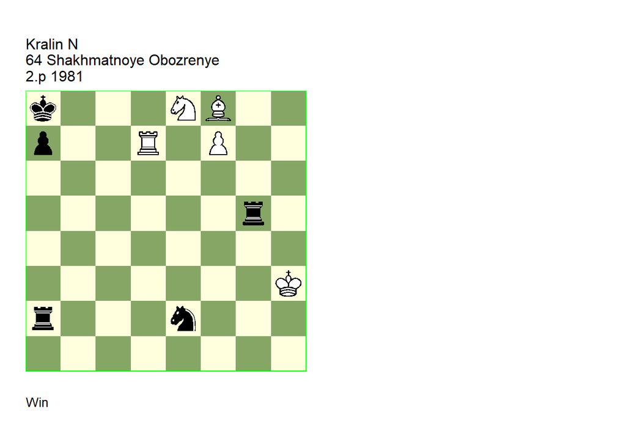

GBR: +0714.11h3a8 U2 FEN: k3NB2/p2R1P2/8/6r1/8/7K/r3n3/8 w - - 0 1

64 Shakhmatnoye Obozrenye=24(647) 64 Shakhmatnoye Obozrenye/12 24/30.p USSR overall champ XVI 1981-1982 Bulletin Central Chess Club USSR=9(313) 1985 EG#05479. U2: Neuenschwander=B beatochess 07/02/2025. **1. Nc7+** (1. Bc5? Rg3+ 2. Kh2 (2. Kh4 Ra4+ 3. Kh5 Nf4+ 4. Kh4 Ne2+ 5. Kh5 Nf4+ 6. Kh6 Ne6 7. Nc7+ Kb8 8. Be7 Ra1) 2… Rf3) **1… Kb8 2. Na6+! Ka8! 3. Bc5 Ng1+! 4. Bxg1 Rh2+! 5. Bxh2!** (5. Kxh2! **cook** **BN** 5… Rg2+ 6. Kh3 Rg3+ 7. Kh4 Rg4+ 8. Kh5 Rg5+ 9. Kh6 Rg6+ 10. Kh7 Rg7+ 11. Kh8 Rh7+ 12. Kg8 Rg7+ 13. Kf8 Rxf7+ 14. Ke8 Re7+ 15. Kd8 Re8+ 16. Kc7 Rc8+ 17. Kd6 Rc6+ 18. Kd5 Rxa6 19. Bh2) **5… Rg3+! 6. Kh4 Rg4+ 7. Kh5 Rg5+ 8. Kh6 Rg6+ 9. Kh7 Rg7+ 10. Kh8 Rh7+! 11. Kg8 Rg7+ 12. Kf8 Rxf7+! 13. Ke8 Re7+ 14. Kd8 Re8+ 15. Kc7 Rc8+ 16. Kd6 Rc6+ 17. Kd5! Rxa6 18. Rd8+ Kb7 19. Rb8# 1-0**.

### Marwitz =0704.10d2h7 (1980). Cook

Date: February 7, 2025

File: Marwitz1980a.pgn

The mainline does not work.

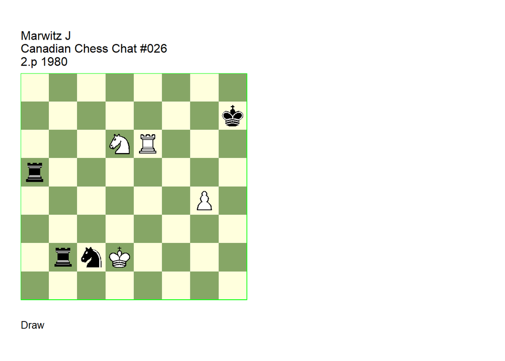

GBR: =0704.10d2h7 U2 FEN: 8/7k/3NR3/r7/6P1/8/1rnK4/8 w - - 0 1

Canadian Chess Chat/7-8 (EG#05506). U2: Garcia=M HHdbII#42473 2-5-2000 U2: Van, der, Heijden=H HHdbIV#47891 25-5-2006. U3: Neuenschwander=B beatochess 07/02/2025. **1. Re7+!** (1. Nc4? Nd4+) (1. Kc3? Rba2) **1… Kh6!** (1… Kg6 2. Nc4 Rd5+ 3. Kc3 Rb4 4. Rc7 Rd4 5. Ne5+! Kg5 6. Nd3) **2. g5+!** (2. Nc4! **cook** MG 2… Rd5+ 3. Kc3 Rb4 4. Rc7 Rd4 5. Rc6+ Kg5 (5… Kg7 6. g5 Kh7 7. Rc7+ Kg8 8. Rc8+) 6. Nd2) **2… Kh5** (2… Rxg5 3. Nf7+) (2… Kxg5 3. Kc1! Rba2 (3… Rb8! **cook** **BN** 4. Ne4+ (4. Kxc2 Rc5+) 4… Kf4 5. Kxc2 Ra2+ 6. Kd3 Rd8+ 7. Kc3 Re2) 4. Ne4+ Kf4 5. Nc3 R2a3 6. Kxc2 Rc5 7. Rf7+ Ke3 8. Re7+ Kd4? 9. Re4#) **3. Nc4 Rd5+ 4. Kc3 Rb4!** (4… Ra2 5. Kb3) **5. Rc7 Rd4! 6. g6! Kh6** (6… Kxg6 7. Ne5+ Kf5 8. Nd3) (6… Rg4 7. g7) **7. Rc6!** (7. g7? Kh7!) (7. Ne5? Ne3! 8. Rh7+ Kg5 9. Nf3+ (9. g7 Nd5+ 10. Kc2 Nf6) 9… Kxg6 10. Nxd4 Nd5+ 11. Kd3 Kxh7) (7. Rc5 Rg4 8. Rc8 Rf4 9. Rc7 Rf2 10. Ne5! **cook** HH 10… Rg2 11. Rh7+ Kg5 12. g7 Kf6 13. Rh2!) (7. Rc8 Rg4 8. Rc7 Rh4 9. Ne5! **cook** HH ) **7… Rf4** (7… Re4 8. Nd6! (8. Nd2? Re2 9. Kd3 Nd4 10. g7+ Kxg7 11. Rc7+ Kf6 12. Nc4 Ne6) 8… Re2 (8… Nd4 9. Kxb4 Nxc6+ 10. Kc5) 9. Nf5+ Kg5 10. g7 Rb8 11. Nh6 Ne1! 12. Nf7+ Kf5 13. Nh6+ Ke5 14. Rc5+ Ke4 (14… Kd6 15. Rb5!) 15. Rc4+) **8. Rc8! Rg4** (8… Re4 9. Nd2! Re2 10. Kd3 (10. Kxc2? Rd4!) 10… Nd4 11. Nc4!) **9. Rc5! Rh4** (9… Re4 10. Nd6! (10. Nd2? Re2 11. Kd3 Nd4 12. Nc4 Ne6) 10… Re2 (10… Re6 11. Nf7+ Kxg6 12. Ne5+ Kf6 13. Nd3) 11. Kd3 Nd4 12. Nf5+) **10. Rc7! Rd4** (10… Re4 11. g7! Kh7 12. Nd2 Re2 13. Kd3 Nd4 14. Nc4 Ne6 15. g8=Q+ Kxg8 16. Rc8+) **11. Rc6! Kg7 12. Rc7+ Kf8 13. Rc8+ Kg7** (13… Ke7 14. g7) **14. Rc7+ Kh6 15. Rc6! 1/2-1/2**.

### Pospisil +4000.10f8h7 (1982). Changed solution

Date: February 9, 2025

File: Pospisil1982a.pgn

Comment: **3. Qc4+** is a loss of time due to **3… Qf5+**, not **3… Qf6+** after which **4. Ke8** wins. The problem can be resolved by changing the mainline.

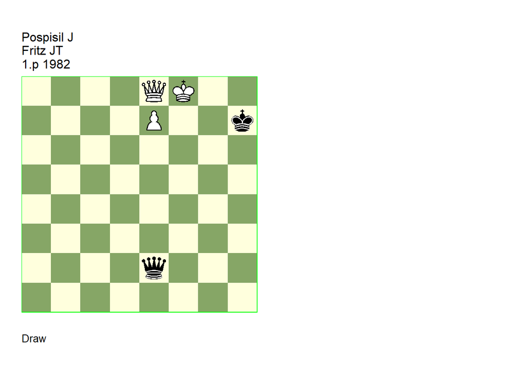

GBR: +4000.10f8h7 (s) FEN: 4QK2/4P2k/8/8/8/8/4q3/8 b - - 0 1

EG#05553. (s) Neuenschwander=B beatochess 09/02/2025. **1… Qe5!** (1… Qg4 **main** 2. Qf7+ Kh8! 3. Qf6+ (3. Qd5? Qf5+! 4. Qxf5) (3. e8=Q? Qb4+ 4. Qfe7 Qf4+) 3… Kh7 4. e8=R! (4. e8=Q? Qg8+ 5. Ke7 Qf8+! 6. Qexf8 (6. Kxf8) (6. Qfxf8) ) ) **2. Qf7+ Kh6 3. e8=R!** (3. e8=Q? Qd6+ 4. Qfe7 Qf4+ 5. Kg8 Qg3+ 6. Kh8 Qe5+ 7. Qxe5) (3. Qc4? Qf6+ (3… Qf5+! 4. Qf7 (4. Ke8? Kg7 =) 4… Qe5) 4. Qf7 (4. Ke8! +- **cook** **BN** 4… Kg7 5. Qg4+) 4… Qe5 ) (3. Kg8? Qg5+ 4. Kf8 Qe5) **1-0**.

### Sochnev +4030.24f5h8 (1982). Comment, correction

Date: February 12, 2025

File: Sochnev1982a.pgn

In the original study and correction, the mainline should end after **10. Kf7**.

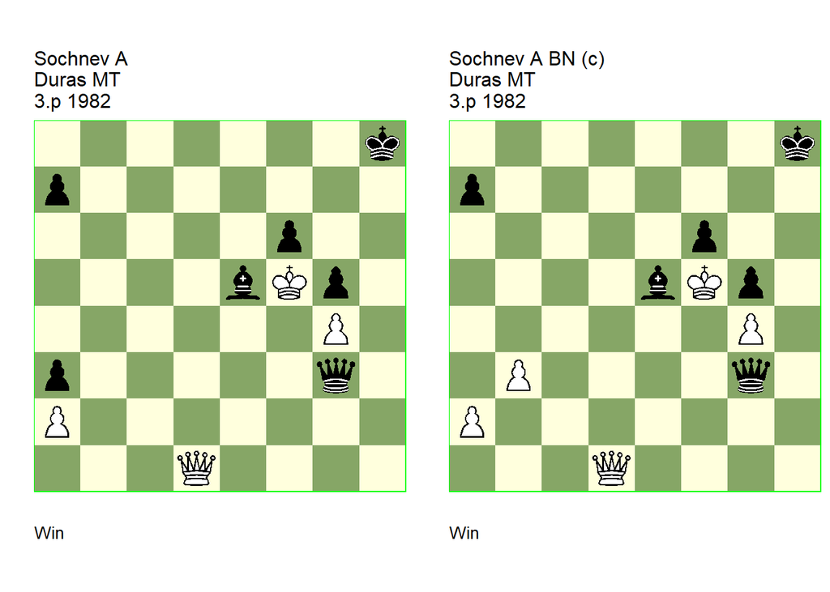

GBR: +4030.24f5h8 U3 (U2) FEN: 7k/p7/5p2/4bKp1/6P1/p5q1/P7/3Q4 w - - 0 1

EG#05643. U3: Pfannkuche=M Deutsche Schachzeitung/8 1984. (U2) Neuenschwander=B beatochess 12/02/2025. **1. Kg6 Bd6 2. Qf1** (2. Qc2? Qxg4 3. Qc6 Qe6) **2… Bf4** (2… Qe5 3. Qb5) (2… f5! **cook** MP 3. Qa6! (3. Qh1+ Qh2 4. Qb7 (4. Qa8+ Bb8 5. Qb7 Qd6+) 4… Bf8!) (3. Qc4 Bc7) (3. Qb5 Bf8) (3. Qxf5 Qc3! (3… Qf4? 4. Qc8+ Qf8 5. Qc3+ Kg8 6. Qb3+ Kh8 7. Qh3+) ) 3… Qc3! 4. Qxd6 (4. Qb7 Qc7 5. Qa8+ Qb8 6. Qh1+ Bh2) 4… Qg7+ 5. Kxf5 Qf7+ 6. Qf6+ (6. Kxg5 Qxa2) 6… Qxf6+ 7. Kxf6 Kg8) **3. Qc4** (3. Qb5? Qe3) (3. Qa6? Qc3) **3… Bc7 4. Qe4 Be5 5. Qd5** (5. Qf5? Qc3) (5. Qc4? Bc7 6. Qe4 Be5) **5… Bd6 6. Qf5 Qc3 7. Qe4 Qe5 8. Qa8+** (8. Qc6? Qe6) **8… Bb8 9. Qc6 Bc7 10. Kf7 Kh7** (10… a5 11. Qd7) **11. Qh1+** e.g. (11. Qf3! or **BN** ) **11… Qh2 12. Qe4+ Kh8 13. Qe8+ Kh7 14. Qg8+ Kh6 15. Qg6# 1-0**.

GBR: +4030.33f5h8 (c) FEN: 7k/p7/5p2/4bKp1/6P1/1P4q1/P7/3Q4 w - - 0 1

correction: Neuenschwander=B beatochess 12/02/2025. **1. Kg6 Bd6 2. Qf1 Bf4** ( 2… f5 3. Qa6 Qc3 4. Qxa7 Qc7 5. Qxc7 Bxc7 6. Kxf5) **3. Qc4 Bc7 4. Qe4 Be5 5. Qd5** (5. Qa8+ Bb8 6. Qe4 Be5) **5… Bd6 6. Qf5 Qc3 7. Qe4 Qe5 8. Qa8+ Bb8 9. Qc6 Bc7 10. Kf7** e.g. **10… Kh7 11. Qh1+** (11. Qf3 or ) **11… Qh2 12. Qe4+ Kh8 13. Qe8+ Kh7 1-0**.

### Janosi =1033.06d4f6 (1983). Cook

Date: February 13, 2025

File: Janosi1983a.pgn

**1… Nc4!** cooks the third position.

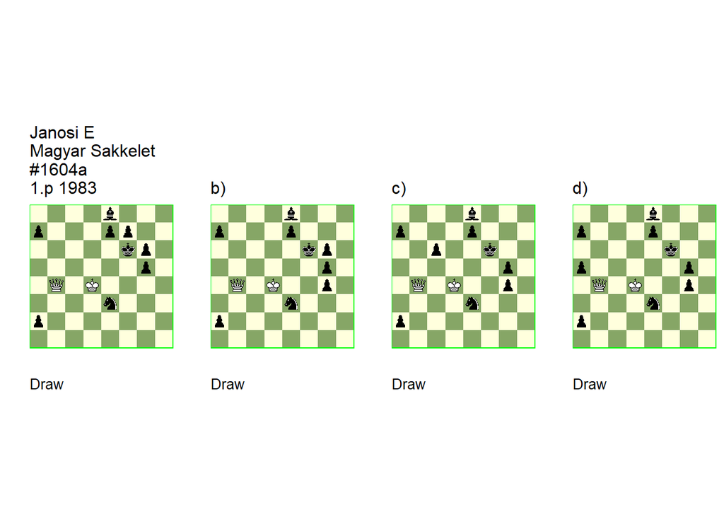

GBR: =1033.06d4f6 TW FEN: 4b3/p3pp2/5kp1/6p1/1Q1K4/4n3/p7/8 w - - 0 1

Magyar Sakkelet/11 (EG#05692a). **1. Kc5!** (1. Qc3? a1=Q!) (1. Qb2? a1=B) (1. Ke4? a1=Q) **1… a1=B** (1… a1=Q **main** 2. Qb2+! Qxb2) **2. Qc3+! Bxc3 1/2-1/2**.

GBR: =1033.06d4f6 TW FEN: 4b3/p3p3/5kp1/6p1/1Q1K2p1/4n3/p7/8 w - - 0 1

Magyar Sakkelet/11 (EG#05692b). **1. Qc3** (1. Ke4? Bc6+!) (1. Kc5? Bf7 2. Qc3+ e5 3. Kd6 Nf5+ 4. Kd7 Nd4) (1. Qb2? a1=B! (1… a1=Q? 2. Kc5+ Qxb2) ) **1… a1=B** (1… a1=Q **main** 2. Ke4+! Qxc3) **2. Kc5+! Bxc3 1/2-1/2**.

GBR: =1033.06d4f6 TW U3 FEN: 4b3/p3p3/2p2k2/6p1/1Q1K2p1/4n3/p7/8 w - - 0 1

Magyar Sakkelet/11 (EG#05692). U3: Neuenschwander=B beatochess 13/02/2025. **1. Ke4** (1. Qb2? a1=B! (1… a1=Q? 2. Kc5+ Qxb2) ) (1. Kc5? Bf7) (1. Qc3? Nf5+ 2. Kd3+ e5 3. Kc2 Nd4+ 4. Kb2 Bf7) **1… Bg6+** (1… a1=Q **main** 2. Qc3+ Qxc3) (1… a1=B 2. Kxe3) (1… Nc4) (1… Nc4! **cook** **BN** 2. Qa4 e5 ) **2. Kxe3 a1=Q 3. Qb2+! Qxb2 1/2-1/2**.

GBR: =1033.06d4f6 TW FEN: 4b3/p3p3/5k2/p5p1/1Q1K2p1/4n3/p7/8 w - - 0 1

Magyar Sakkelet/11 (EG#05692d). **1. Qb2!** (1. Qc3? Nf5+) **1… a1=Q** (1… a1=B **main** 2. Kc5+! Bxb2) **2. Kc5+! Qxb2 1/2-1/2**.

### Pogosyants +0441.00c1g4 (1983). Correction

Date: February 13, 2025

File: Pogosyants1983a.pgn

Shifting the position one file to the right saves the study. Note that 53% of all GBR-class 0441.00 endings are winning.

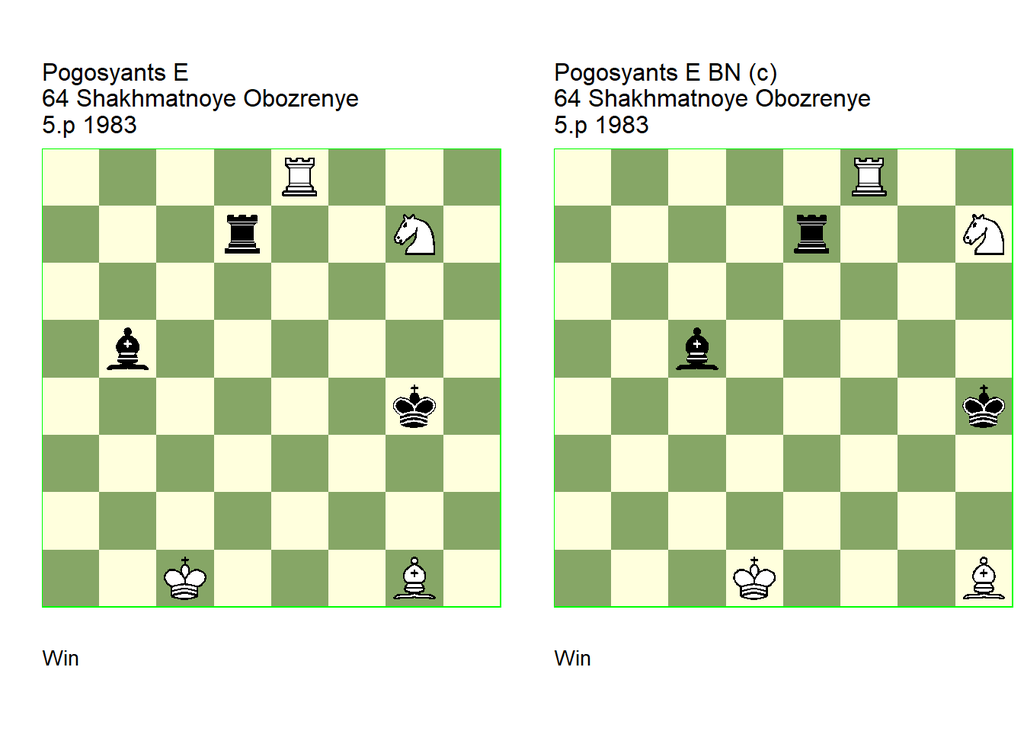

GBR: +0441.00c1g4 U3 FEN: 4R3/3r2N1/8/1b6/6k1/8/8/2K3B1 w - - 0 1

64 Shakhmatnoye Obozrenye=6(677) 64 Shakhmatnoye Obozrenye/3 (EG#05741). U3: Vlasak=E Ceskoslovensky Sach/12 2005. **1. Rg8! Bc4 2. Ne6+ Kf5** (2… Kf3! **cook** EV 3. Rf8+ Kg2! 4. Nc5 Rf7! 5. Rg8+ Kh1!) **3. Nd4+ Rxd4! 4. Rf8+ Ke4** (4… Ke5 5. Re8+ Be6 6. Bxd4+) **5. Re8+ Kd3 6. Re3# 1-0**.

GBR: +0441.00d1h4 (c) FEN: 5R2/4r2N/8/2b5/7k/8/8/3K3B w - - 0 1

correction: Neuenschwander=B beatochess 13/02/2025. **1. Rh8 Bd4 2. Nf6+ Kg5** ( 2… Kg3 3. Rg8+! Kh2 4. Nd5! Rg7 5. Rh8+! +-) **3. Ne4+ Rxe4 4. Rg8+ Kf4 5. Rf8+ Ke3** (5… Ke5 6. Re8+) **6. Rf3# 1-0**.

### Joitsa =0011.03g6h4 (1982). Cook

Date: February 14, 2025

File: Joitsa1982a.pgn

**11. Bg1!** cooks the study.

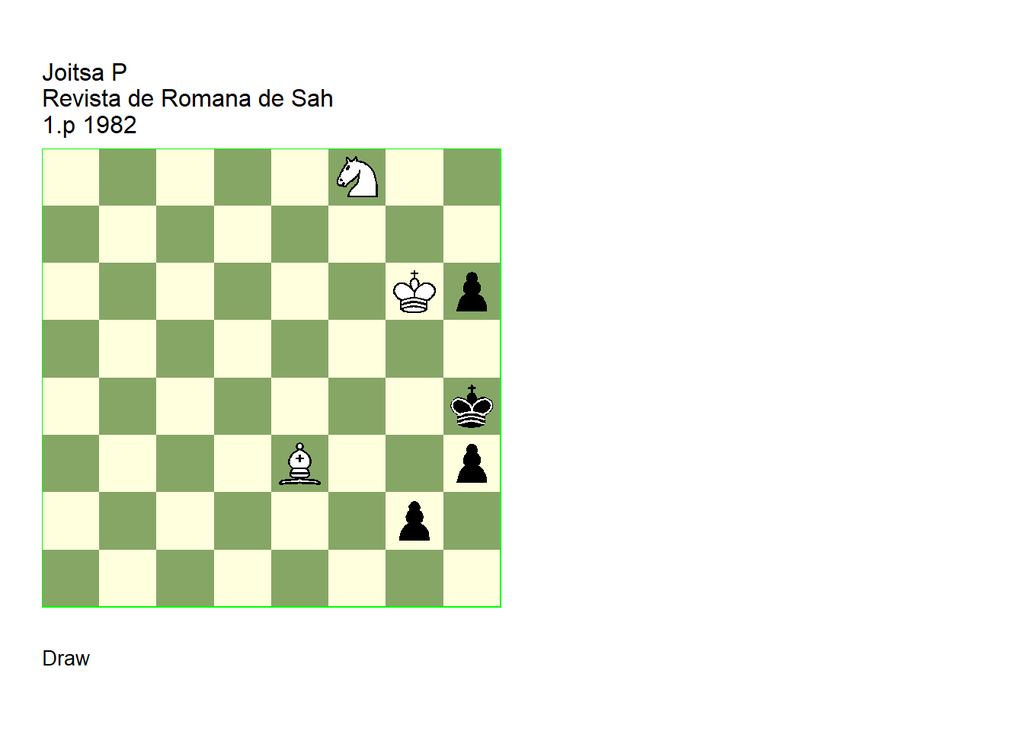

GBR: =0011.03g6h4 U2 FEN: 5N2/8/6Kp/8/7k/4B2p/6p1/8 w - - 0 1

Revista de Romana de Sah/1 (EG#05767). U2: Neuenschwander=B beatochess 14/02/2025. **1. Kf5!** (1. Bg1? Kg3 2. Ne6 h2 3. Bxh2+ Kxh2 4. Nd4 g1=Q+) **1… h2** (1… Kg3 2. Ng6 h2 3. Bf4+ Kh3 4. Bxh2 Kxh2 5. Nh4) **2. Ng6+ Kh3! 3. Nf4+ Kg3 4. Ne2+ Kf3 5. Bg1! h1=Q 6. Nd4+ Kg3 7. Ne2+ Kh3 8. Nf4+ Kg3 9. Ne2+ Kh4 10. Bf2+ Kh3 11. Ng1+!** (11. Bg1! **cook** **BN** ) **11… Kh2 12. Nf3+ 1/2-1/2**.

### Nestorescu +0471.11d5a3 (1982). Cook

Date: February 14, 2025

File: Nestorescu1982a.pgn

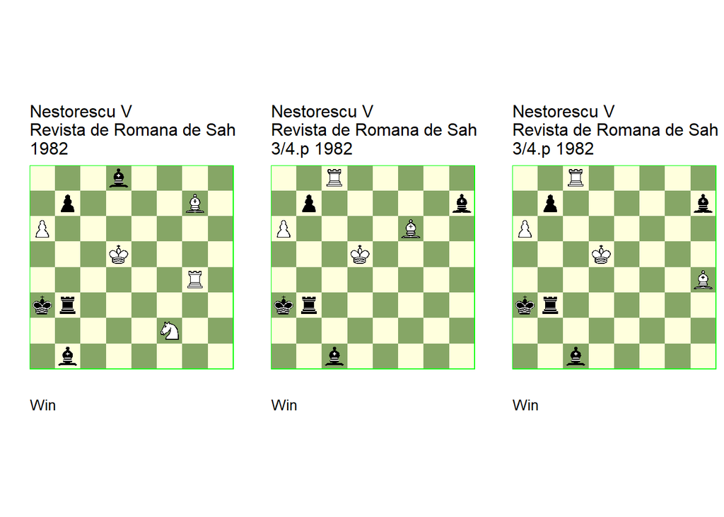

GBR: +0471.11d5a3 U2 FEN: 3b4/1p4B1/P7/3K4/6R1/kr6/5N2/1b6 w - - 0 1

Revista de Romana de Sah/5. U2: Neuenschwandere=B beatochess 14/02/2025. **1. Bf8+** (1. a7? Rb5+ 2. Kc4 Ra5 3. Rg3+ Ka4 4. Bd4 b6) **1… Kb2 2. Nd1+** (2. a7? Rb5+ 3. Kc4 (3. Bc5! **cook** **BN** 3… Ra5 4. Rb4+ Kc2 5. Rxb7 Bb6 6. Rxb6 Rxa7 7. Rxb1 Rd7+ 8. Kc6) 3… Ra5 4. Bg7+ Kc2) **2… Kc1 3. Rc4+ Kxd1 4. a7 Rb5+** (4… Rd3+ 5. Ke5! Bf6+ 6. Kxf6 Rd8 7. Rd4+!) **5. Rc5 Ba2+ 6. Ke5!** ( 6. Kd6? Rb6+ 7. Kd7 Ra6) **6… Bc7+** (6… Bf6+ 7. Kf5! Bb1+ 8. Kxf6 Rb6+ 9. Ke5 Ra6 10. Rd5+ Ke2 11. Bc5 b6 12. Bxb6 Kf3 13. Rd8 Be4 14. Rf8+) **7. Kf5! Bb1+ 8. Kg5 Bd8+ 9. Kh5! Bg6+ 10. Kh6! 1-0**.

GBR: +0470.11d5a3 (v) FEN: 2R5/1p5b/P4B2/3K4/8/kr6/8/2b5 w - - 0 1

Revista de Romana de Sah/5 (EG#05770). **1. Be7+** (1. a7? Rb5+ 2. Kd6 (2. Rc5 Bg8+ 3. Kd6 (3. Ke4 Rb4+ 4. Bd4 Ra4 5. Rxc1 b6 6. Rc7 Be6 7. Ke5 Bh3 8. Bxb6 Bg2) 3… Rb6+) (2. Ke6 Ra5 3. Rxc1 Bg8+ 4. Ke7 Rxa7 5. Ra1+ Ba2) (2. Kc4 Ra5 3. a8=Q b5+ 4. Kc3 Bb2+) 2… Bf4+) **1… Ka2 2. a7 Rb5+ 3. Rc5 Bg8+** (3… Be4+ 4. Ke5 Bb2+ 5. Kf4!) **4. Ke5! Bb2+** (4… Bf4+ 5. Kf5 Bh7+ 6. Kg4!) **5. Kf5! Bh7+ 6. Kg5! Bc1+ 7. Kh5! Bg6+ 8. Kxg6 Rb6+ 9. Bf6! Ra6 10. Rxc1 Kb3** ( 10… Rxa7 11. Ra1+) **11. Ra1 1-0**.

GBR: +0470.11d5a3 (m) FEN: 2R5/1p5b/P7/3K4/7B/kr6/8/2b5 w - - 0 1

Revista de Romana de Sah/5. modification: Endgame Magic (2nd ed)#14.8 2017. **1. Be7+** (1. a7? Rb5+ 2. Rc5 Bg8+ 3. Kd6 (3. Ke4 Rb4+) 3… Rb6+) **1… Ka2 2. a7 Rb5+ 3. Rc5 Bg8+** (3… Be4+ 4. Ke5 Bb2+ 5. Kf4 Bc1+ 6. Kg4) **4. Ke5 Bb2+ 5. Kf5 Bh7+ 6. Kg5 Bc1+ 7. Kh5 Bg6+ 8. Kxg6 Rb6+ 9. Bf6 Ra6 10. Rxc1 Rxa7 11. Ra1+ Kb3 12. Rxa7 1-0**.

### Falk =0433.12c4e3 (1985). Cook, correction

Date: February 16, 2025

File: Falk1985a.pgn

The interactions with Lars Falk in the 1980s brings back happy memories.

There is a cook in the second mainline **3… Bd2**, which can be fixed by shifting the position one file to the right.

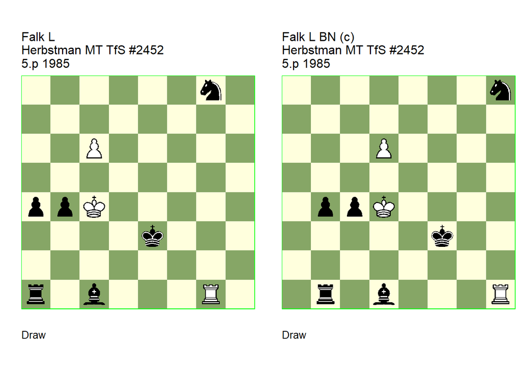

GBR: =0433.12c4e3 U2 FEN: 6n1/8/2P5/8/ppK5/4k3/8/r1b3R1 w - - 0 1

Tidskrift for Schack=8 Tidskrift for Schack/10 (EG#05794). U2: Neuenshwander=B beatochess 16/02/2025 . **1. c7** (1. Re1+? Kd2 2. c7 Ra2) (1. Rxg8? Bd2 2. Re8+ Kf3 3. Rf8+ (3. Kd3 Bf4) 3… Ke2 4. Re8+ Kd1) **1… Ne7 2. Re1+ Kf3 3. Rxe7 Ba3** (3… Bd2 **main** 4. Kd3 Rc1 (4… Rd1 5. Kc2 Rc1+ 6. Kxd2) 5. Kxd2 ( 5. Re3+? Bxe3 6. c8=Q Rc3+! (6… Rxc8?) ) 5… Rc6 6. Kd3! (6. Re3+? Kf4 7. Rh3 Kg5 8. Rd3 Rxc7) (6. Rf7+? Kg3 (6… Ke4? 7. Rh7 Kd5 8. Rh4 Kc5 9. Kd3 Kb5 10. Rh5+ Kb6 11. Rh4) 7. Rg7+ (7. Rd7 a3) (7. Re7! **cook** **BN** 7… a3 (7… Kf4 8. Kd3 Rc3+ 9. Kd4 a3 10. Re4+) 8. Re3+ Kf4 9. Rb3) 7… Kf4 8. Rf7+ (8. Rh7 Kg5 9. Re7 b3) (8. c8=Q Rxc8 9. Rb7 (9. Ra7 a3 10. Ra4 Rc4) 9… Rd8+ (9… Rc4? 10. Kd3 Rc3+ 11. Kd4) 10. Kc2 Rd4 11. Ra7 Rc4+ 12. Kb2 b3) 8… Ke5 9. Rh7 b3 10. Rh5+ Kd4 11. Rh4+ Kc5 12. Rxa4 b2 13. Ra3 b1=N+) 6… b3 (6… Rc3+ 7. Kd2 Rc4 8. Kd3 Rc3+ 9. Kd2 Kf4 10. Rh7 Kg5 11. Rd7 a3 12. Rd5+ Kf6 13. Rb5 a2 14. Ra5) 7. Re3+! Kf2 8. Re4 a3 9. Rc4 Rxc4 (9… Rd6+ 10. Kc3 a2 11. Ra4) (9… b2 10. Rxc6 b1=Q+ 11. Rc2+) (9… Rxc7 10. Rxc7 a2 11. Ra7 b2 12. Rxa2) 10. Kxc4 eg 10… b2 11. c8=Q b1=Q 12. Qf8+) **4. Rf7+ Ke3 5. Re7+ Kd2 6. Rd7+ Ke2** (6… Ke3 7. Rd3+ Ke2 8. Rc3) **7. Re7+ Kf3 8. Rf7+ Kg3 9. Rg7+** (9. Kb5? Rc1 10. Kxa4 Rc5 11. Kb3 Kg4 12. Rd7 Rc3+ 13. Ka4 Kf5 14. Kb5 Ke6 15. Rh7 Kd6 16. Kb6 b3 17. Rh6+ (17. Rh3 Rc6+ 18. Kb5 b2) 17… Kd7 18. Rh7+ Be7) **9… Kf3** (9… Kh4 10. Rg4+ (10. Kb5? Rc1 11. Rd7 Kg3 12. Kxa4 Rc5 13. Kb3 Kf3 14. Rh7 (14. Ka4 Kf4) 14… Kg4 15. Rd7 Rc3+ 16. Ka4 Kf5) 10… Kh5 11. Kb5) **10. Rf7+ Ke4 11. Re7+ Kf4 12. Rf7+ Ke5** (12… Kg5 13. Rf5+! (13. Kb5? Rc1 14. Rd7 b3 15. Rd5+ Kf6 16. Kxa4 b2 17. Rb5 Ra1 18. Rb3 Bd6+) 13… Kg6 14. Kb5 Rc1 15. Rc5 Rxc5+ 16. Kxc5 b3+ 17. Kd5 b2 18. c8=Q b1=Q 19. Qc6+ Kf5 20. Qxa4) **13. Re7+** (13. Rf5+? Kd6! 14. c8=N+ Ke6) **13… Kd6** (13… Kf6 14. Re6+ Kf7 15. Rc6) **14. c8=N+ Kc6 15. Na7+ Kb6 16. Nc8+ Kc6** (16… Ka6 17. Ra7#) **17. Na7+ 1/2-1/2**.

GBR: =0433.12d4f3 (c) FEN: 7n/8/3P4/8/1ppK4/5k2/8/1r1b3R w - - 0 1

correction: Neuenschwander=B beatochess 16/02/2025. **1. d7 Nf7 2. Rf1+ Kg3 3. Rxf7 Bb3** (3… Be2 **main** 4. Ke3 Rd1 5. Kxe2 Rd6 6. Ke3 (6. Rg7+? Kf4 7. Rh7 Ke5 8. Rh5+ Ke4 9. Rh4+ Kd5 10. Ke3 Rxd7 11. Rd4+ Kc6 12. Rxc4+ Kb5) 6… b3 7. Rf3+) **4. Rg7+ Kf3 5. Rf7+ Ke2 6. Re7+ Kf2 7. Rf7+ Kg3 8. Rg7+ Kf4 9. Rf7+ Kg4 10. Rg7+ Kf5** (10… Kh5 11. Rg5+) **11. Rf7+ Ke6** (11… Kg6? 12. Rf6+) **12. d8=N+ Kd6 13. Nb7+ Kc6 14. Nd8+ Kd6 15. Nb7+ Kc6 16. Nd8+ Kb6 17. Rb7+ 1/2-1/2**.

### Slepyan +0344.32g5d5 (1984). Comment

Date: February 21, 2025

File: Slepyan1984a.pgn

The version appears to be a correction of the first study, in which White is only slightly better at the end of the study.

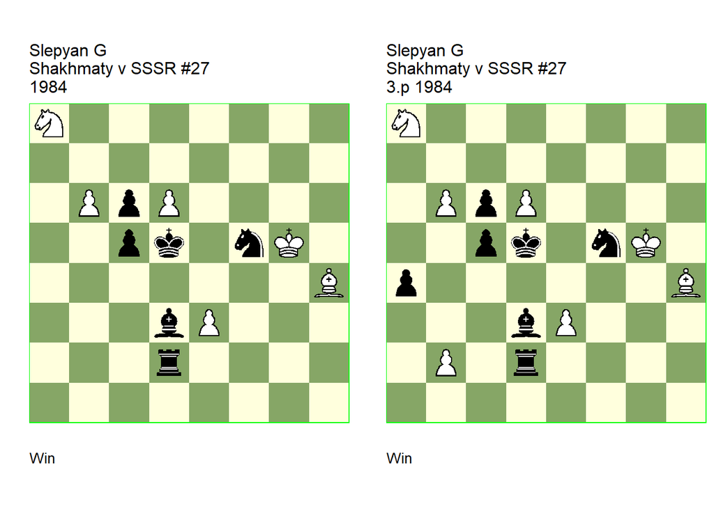

GBR: +0344.32g5d5 U3 FEN: N7/8/1PpP4/2pk1nK1/7B/3bP3/3r4/8 w - - 0 1

Shakhmaty v SSSR/7. U3: Neuenschwander=B beatochess 21/02.2025. **1. d7!** (1. b7? Rg2+ 2. Kf4 Rg8 3. d7 Nd6) **1… Ke5!** (1… Rg2+ 2. Kf4 Rg8 3. Nc7+ Kd6 4. d8=Q+ Rxd8 5. Bxd8) **2. Bg3+!** (2. d8=Q? Rg2+ 3. Kh5 Be2#) **2… Nxg3 3. d8=Q Ne4+ 4. Kh6 Rh2+ 5. Kg7 Rh7+! 6. Kxh7 Ng5+ 7. Kg8! Bc4+ 8. Qd5+! Bxd5+ 9. Kf8 Kd6! 10. b7 Ne6+ 11. Ke8** (11. Kg8? Nd8+) **11… Nc7+ 12. Kd8 Na6 13. Nc7! Nb8 14. Kc8 Nd7** (14… c4 15. Kxb8 c3 16. Kc8 c2 17. b8=Q c1=Q 18. Qb4+ c5 19. Qf4+) **15. Ne8+ Ke6 16. Nf6! Nxf6** ( **cook** **BN** ) **17. b8=Q c4** (White’s advantage is minimal) **1-0**.

GBR: +0344.43g5d5 (v) FEN: N7/8/1PpP4/2pk1nK1/p6B/3bP3/1P1r4/8 w - - 0 1

Shakhmaty v SSSR/7 11/16.p USSR overall champ XVII 1983-1984 Bulletin Central Chess Club USSR=22(392) Bulletin Central Chess Club USSR/8 1987 (EG#05833). version: Shakhmaty v SSSR/5 1985. **1. d7!** (1. b7? Rg2+ 2. Kf4 Rg8 3. d7 Nd6 ) **1… Ke5!** (1… Rg2+ 2. Kf4 Rg8 3. Nc7+ Kd6 4. d8=Q+ Rxd8 5. Bxd8) **2. Bg3+!** (2. d8=Q? Rg2+ 3. Bg3+ Rxg3+ 4. Kh5 Be2#) **2… Nxg3 3. d8=Q** (3. b7? Ne4+ 4. Kh6 Rh2+ 5. Kg7 Rh7+! 6. Kxh7 Nf6+ 7. Kg7 Nxd7) **3… Ne4+ 4. Kh6 Rh2+ 5. Kg7! Rh7+! 6. Kxh7 Ng5+ 7. Kg8! Bc4+ 8. Qd5+!** (8. Kf8? Ne6+ 9. Ke7 Nxd8 10. Kxd8 Ba6!) **8… Bxd5+ 9. Kf8 Kd6** (9… Kf6 **main** 10. e4! (10. b7? Bf7 11. b8=Q Nh7#) (10. Ke8? Ne4 11. Kd7 c4) (10. Nc7? Bf7 11. Ne8+ Bxe8 12. Kxe8 a3 13. bxa3 Ne4 14. Kd7 c4 15. Kxc6 c3) 10… Ne6+ 11. Ke8 Ng7+ 12. Kd7 Be6+ 13. Kd8) **10. b7** (10. Ke8? Bf7+ 11. Kd8 Ne6+ 12. Kc8 Be8 13. b7 Bd7+ 14. Kb8 Nd8) **10… Ne6+ 11. Ke8** (11. Kg8? Nd8+) **11… Nc7+ 12. Kd8 Na6 13. Nc7! Nb8 14. Kc8 Nd7** (14… c4 15. Kxb8 c3 16. Kc8 c2 17. b8=Q c1=Q 18. Qb4+ c5 19. Qf4+) **15. Ne8+ Ke7** (15… Ke6 16. Nf6!) **16. Nf6! 1-0**.

### Maksimovskikh & Shupletsov=0140.01e8d1 (1985). No cook, changed solution

Date: February 22, 2025

File: Maksimovskikh1985a.pgn

After changing the solution, which does not affect the contents of the study, the study is correct.

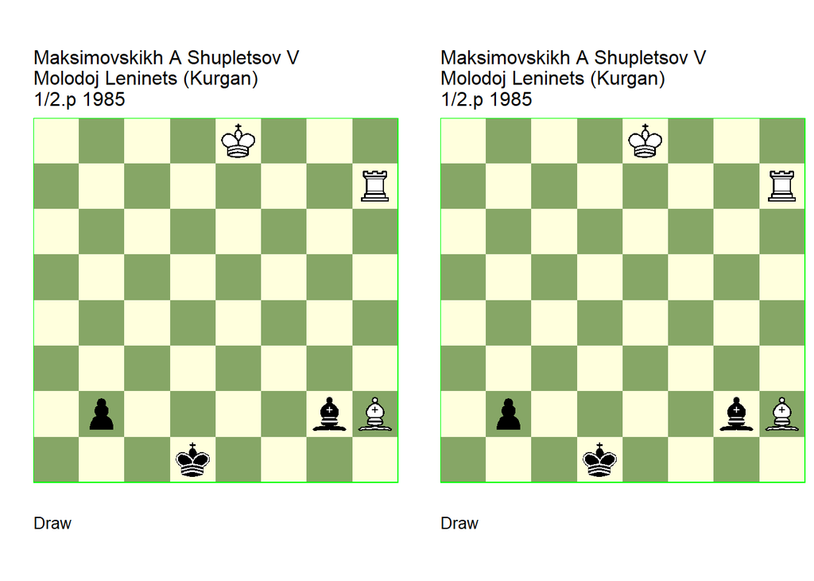

GBR: =0140.01e8d1 U2 FEN: 4K3/7R/8/8/8/8/1p4bB/3k4 w - - 0 1

21/34.p USSR overall champ XVIII 1985-1986 Bulletin Central Chess Club USSR=19(461) Bulletin Central Chess Club USSR/7 1989 (EG#05875). U2: Pallier=A HHdbIV#53292 23-10-2006. **1. Rd7+ Kc2! 2. Rc7+ Kb3! 3. Rc8!** (3. Rc3+? Ka4! 4. Rc4+ Kb5 5. Rc8 Bb7! 6. Rb8 Ka6) **3… Ka4 4. Rb8!** (4. Rc4+? Kb5 5. Rc8 Ka6 6. Rb8 Bb7) **4… Bc6+ 5. Ke7!** (5. Kf8? Bb5 6. Ra8+ Kb3 7. Rb8 Kb4 8. Bd6+ Ka5 9. Bc7+ Ka4 10. Ra8+ Kb3 11. Rb8 Kc4!) **5… Bb5 6. Ra8+ Kb3 7. Rb8 Kc4 8. Rc8+ Kb3 9. Rb8** (9. Rc3+! **cook** AP) **9… Kb4 10. Bd6+ Kc4** ( 10… Ka5 11. Ra8+ Ba6 12. Rb8 Bb5 13. Ra8+ Kb6 14. Rb8+ Kc6 15. Rc8+ Kb7 16. Rb8+) **11. Rc8+ Kd3** (11… Kd4 12. Be5+ Kxe5 13. Rc5+) **12. Rc3+ Kxc3 13. Be5+ 1/2-1/2**.

GBR: =0140.01e8d1 (s) FEN: 4K3/7R/8/8/8/8/1p4bB/3k4 w - - 0 1

21/34.p USSR overall champ XVIII 1985-1986 Bulletin Central Chess Club USSR=19(461) Bulletin Central Chess Club USSR/7 1989 (EG#05875). U2: Pallier=A HHdbIV#53292 23-10-2006. Changed solution: Neuenschwander=B beatochess 22/02/2025. **1. Rd7+ Kc2! 2. Rc7+ Kb3! 3. Rc8!** (3. Rc3+? Ka4! 4. Rc4+ Kb5 5. Rc8 Bb7! 6. Rb8 Ka6) **3… Ka4 4. Rb8!** (4. Rc4+? Kb5 5. Rc8 Ka6 6. Rb8 Bb7) **4… Bc6+ 5. Ke7!** (5. Kf8? Bb5 6. Ra8+ Kb3 7. Rb8 Kb4 8. Bd6+ Ka5 9. Bc7+ Ka4 10. Ra8+ Kb3 11. Rb8 Kc4!) **5… Bb5 6. Ra8+ Kb3 7. Rb8 Kb4** (7… Kc4 8. Rc8+ Kd3 9. Rc3+) **8. Bd6+ Kc4 9. Rc8+ Kd3** (9… Kd4 10. Be5+) **10. Rc3+ Kxc3 11. Be5+ 1/2-1/2**.

### Dobrescu =0867.10e5a6 (1979a). Cook

Date: February 28, 2025

File: Dobrescu1979a.pgn

Black wins (according to tablebase) after **8… Rc3+ 9. Rxh4 Rxc1 10. Rxh8 Bb5!**

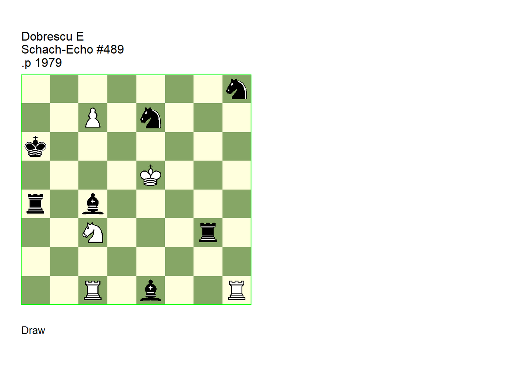

GBR: =0867.10e5a6 U3 FEN: 7n/2P1n3/k7/4K3/r1b5/2N3r1/8/2R1b2R w - - 0 1

Schach-Echo=13-14 Schach-Echo/7 1980 (EG#05892). U3: Neuenschwander=B beatochess 28/02/2025. **1. c8=Q+!** (1. Nxa4? Nhg6+) **1… Nxc8 2. Nxa4 Rg5+ 3. Kd4! Rg4+ 4. Ke3!** (4. Ke5? Bg3+ 5. Kf5 (5. Kf6 Rg6+) 5… Rf4+ 6. Kg5 Nf7+ 7. Kh5 Be2+ 8. Kg6 Ne7+) **4… Rg3+ 5. Kd4** (5. Kf4? Ng6+) (5. Ke4? Nd6+) **5… Rg4+ 6. Ke3 Bh4 7. Kf3** (7. Nb2? Nd6 8. Kf3 (8. Nxc4 Nxc4+ 9. Kf3 Ne5+) 8… Rd4 9. Ke3 Nf5+) **7… Rg3+** (7… Be6 8. Rc6+ Ka5 9. Rxe6 Rxa4 10. Rh6) **8. Kf2 Rh3+** (8… Rc3+ 9. Rxh4 Rxc1 10. Rxh8 Bb5! **cook** **BN** wins (tablebase) ) **9. Kg2** (9. Kg1? Rxh1+ 10. Kxh1 Bd5+) **9… Rg3+** (9… Rxh1 10. Rxc4) **10. Kf2!** (10. Kh2? Rg4 11. Kh3 Rd4) **10… Rg4+ 11. Kf3 Rd4 12. Ke3** ( 12. Nc5+? Kb5 13. Ne4 Ng6) (12. Nb2? Nd6 13. Ke3 Nf5+) **12… Rd3+** (12… Bf6 13. Rh6) **13. Ke2 Rc3+** (13… Rh3+ 14. Rxc4 Rxh1 15. Rxc8) **14. Kd2!** (14. Kd1? Rxc1+ 15. Kxc1 Bg5+) **14… Rd3+** (14… Rxc1 15. Rxh4) **15. Ke2** (15. Kc2? Rd4 16. Kc3 Rg4) **15… Rd4+** (15… Kb5 16. Rxc4 Kxc4 17. Nb2+) **16. Ke3 Rg4 17. Kf3 1/2-1/2**.